# 20240228_pef_qmra_v01

# A case study for milk treatment

## Initial concentration

We will define our initial concentration as a uniform distribution over 0-1 log CFU/g. It has some variability which is defined in level 0.

```r
logN0 <- Uniform$new("logN0", # A uniform distribution
                 level = 0)$
  map_input("min",
            Constant$new("logN0_min", 0) # with a constant min. value
)$
  map_input ("max",
             Constant$new("logN0_max", 1) # and a constant max. value
)
```

## Inactivation using PEF processing

Let’s start with the secondary model:

```r
# Define the C parameter of our equation
chlorine <- Constant$new("chlorine", 50)

#Define the intercept and the slope of our secondary model of our linear inactivation model. the slope is a normal distribution which is firstly defined

k_slope <- Normal$new("k_slope", level = 1)$
  map_input("mu", Constant$new("k_slope_mu", 0.0069))$
  map_input("sigma", Constant$new("k_slope_sigma", 0.0001))

k_chlorine <- LinealModel$new("k_chlorine")$
  map_input("a",
            Constant$new("k_intercept", -0.1811)
            )$
  map_input("b", k_slope)$
  map_input("x", chlorine)
```

For our primary model we will use the processing time of 20 seconds, and we will incorporate the secondary model that we have just defined. The log-linear inactivation parameterized based on the inactivation rate *k* is named LogLinInactivation_k in biorisk:

```r
t_chlorine <- Constant$new("t_chlorine", 20) # the treatment time (s)

inactivation <- LogLinInactivation_k$new("Treatment")$
  map_input("logN0", logN0)$ #We map logN0 to the initial count defined before
  map_input("k", k_chlorine)$
  map_input("t", t_chlorine)
```

## Growth during storage

In this section we will describe the microbial growth during storage using the exponential growth model with stationary phase (bilinear model):

$$\log N =
\begin{cases}
\log N_0 + \mu \cdot t & \text{if } \log N_0 + \mu \cdot t < \log N_{\text{max}} \\
\log N_{\text{max}} & \text{otherwise}
\end{cases}$$

with the growth rate given by the Ratkowsky model:

$$\mu = b\cdot(T - T_{\text{min}})^2$$
As above, we first need to define the secondary model. The Ratkowsky model has three inputs: treatment temperature, *T*<sub>min</sub>, and *b*. For the temperature, we assign a normal distribution that represents uncertainty (level = 1) with expected value (mean) of 6.35 and a standard deviation of 2.83.

```r
temp_distrib <- Normal$new("temp_distrib",
                           level = 1)$ # a normal distribution
  map_input("mu",
            Constant$new("mu_temp_distrib", 6.35) # with a constant mean
)$
  map_input("sigma",
            Constant$new("sd_temp_distrib", 2.83) # and a constant variance
)
```

Then, we define the Ratkowsky model, mapping the temperature to the element we just defined. In this case, we assume no variability or uncertainty in the model parameters, and the *b* is assumed to be 0.014 and *T<sub>min</sub>* to be 1.6.

```r
mu_distrib <- Ratkowsky_model$new("mu_distrib")$ #the Ratkowsky seondary model
  map_input("b",
            Constant$new("b_distrib", 0.0144) #with constant b
)$
  map_input("Tmin",
            Constant$new("Tmin_distrib", 1.6) # and constant Tmin
)$
  map_input("temperature",
            temp_distrib
)
```

Now, we can go back to the primary growth model and integrate our secondary model there. As mentioned above, the model to be used is the ExponentialGrowthNmax. The only input left to assign is the storage time, for which we will assume an exponential distribution with rate parameter 1/29.

```r
time_distrib <- Exponential$new("time_distrib")$ # an exponential distribution
  map_input("rate",
            Constant$new("rate_time_distrib", 1/29)# with constant rate parameter
)
```

Now, we have everything and we will implement the ExponentialGrowthNmax as our primary model. For the treatment time, we will use the storage time that we just defined. The growth rate $\mu$ is already mapped to the output of the Ratkowsky model. Then, the initial concentration at storage needs to be mapped to the output of the inactivation model (to be our reference logN0 for this stage). Finally, we will define a constant *N<sub>max</sub>* of 8 log CFU/g.

```r
growth_distrib <- ExponentialGrowthNmax$new("growth_distrib")$
  map_input("t",
            time_distrib # we assign the element from above to define the time
)$
  map_input("mu",
            mu_distrib # we assign the element from above to define the growth rate
)$
  map_input("logN0",
            inactivation # and logN0 to the output of the chlorine now
)$
  map_input("logNmax",
            Constant$new("logNmax", 8) # A constant logNmax
            )
```

The next step is to convert the microbial concentration (in log CFU/g) to microbial dose cosumed. For this, we will use the Concentration2Dose element. This element considers the fact that the dose is a sampling process (i.e., the output is a discrete number of cells). (In order to obtain continuous values for the dose (e.g., a dose of 0.23 cells), one must use Concentration2Dose_continous).

We have two inputs for the dose response model i.e., the microbial exposure at exposure and the serving size. For the latter, we use a uniform distribution that represents uncertainty (level = 1). For the microbial concentration, we map the output of the growth element from above.

```r
serving_size <- Uniform$new("size", level = 1)$
  map_input("min", Constant$new("min_size", 200))$
  map_input("max", Constant$new("max_size", 500))

consumer_dose <- Concentration2Dose$new("dose")$
  map_input("logN", growth_distrib)$
  map_input("size", serving_size)
```

## Risk characterization

For this stage we need first to define a dose response model. We will use the exponential dose response model with $r = 10^{-12}$, assuming contant pathogen-host survival probability.

```r
Pill <- DoseResponse_Exponential$new("Pill")$
  map_input("r", Constant$new("r_dr", 1e-12))$
  map_input("dose", consumer_dose)
```

Then, we can estimate the number of cases. For that, **biorisk** includes the Pill2Cases_N element to convert from probability of illness to number of cases.This element considers for each Monte Carlo iteration that the nservings have the same probability of illness. On the other hand, the element Pill2Cases_1 considers a single serving per Pill . In this case, we will make the calculations per $10^{12}$ servings.

```r
cases <- Pill2Cases_N$new("cases")$
  map_input("Pill", Pill)$
  map_input("servings", Constant$new("n_servings", 1e12))
```

## Checks, simulation and visualization

We can start with the simplest approach to see what would be the approximate, discrete prediction of the cases per $10^{12}$ servings.

```r
cases$point_estimate()
```

```
[1] 2340.98
```

### Simulation as a 1D Monte Carlo

Then, we continue with our 1D Monte Carlo:

```r
cases$simulate(100000, seed = 241)
```

We can now visualize the number of cases per $10^{12}$ servings, as a histogram. We will use the log transform due to the heavy tail, but this removes also the 0s i.e., the simulations that lead to 0 cases. Therefore we also need to know how many are the 0s in our simulations (it’s in the warning created). We will also add a discrete line with the approximate as estimated before. (Note that this is quite biased with respect to the histogram. The reasons for this is the use of asymmetric distributions and the nonlinear models.)

```
Warning in scale_x_log10(): log-10 transformation introduced infinite values.
```

```
Warning: Removed 55638 rows containing non-finite outside the scale range
(`stat_bin()`).
```

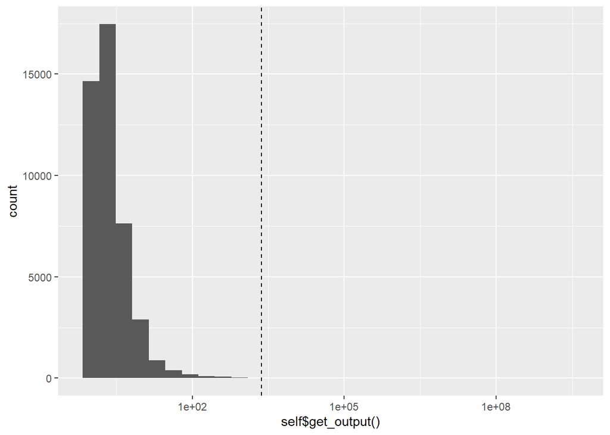

```r
cases$histogram(add_discrete = TRUE) + scale_x_log10()
```

Then, we can also visualize other elements such as the microbial concentration at the end of storsage as a density plot (again with a discrete dashed line, “TRUE”).

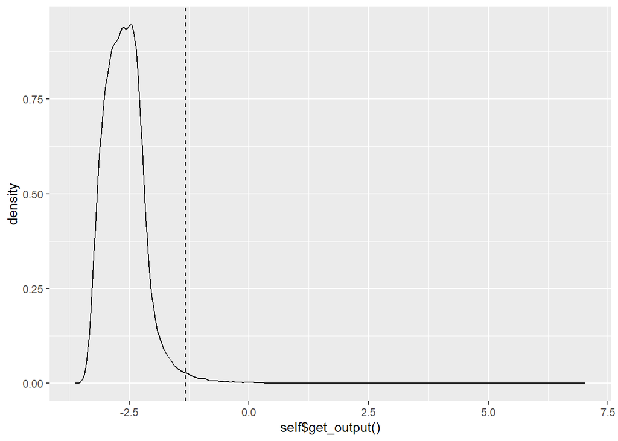

```r
growth_distrib$density_plot(TRUE)
```

Now we will take a look at the quantiles

```r
quantile_table(cases, chosen = c("cases", "Pill", "dose", "growth_distrib"),
               probs = c(0.50, 0.90, 0.99))
```

```
# A tibble: 4 × 4
  node               `50%`     `90%`     `99%`
  <chr>              <dbl>     <dbl>     <dbl>
1 growth_distrib -2.62e+ 0 -2.12e+ 0 -1.20e+ 0
2 dose            1   e+ 0  3   e+ 0  2.3 e+ 1
3 Pill            1.00e-12  3.00e-12  2.30e-11
4 cases           0         4   e+ 0  2.4 e+ 1
```

It would also be nice to monitor the variation of the microbial concentration on each step. We will do this with three ways namely, box plot, violin plot and density plot.

**Box plot**

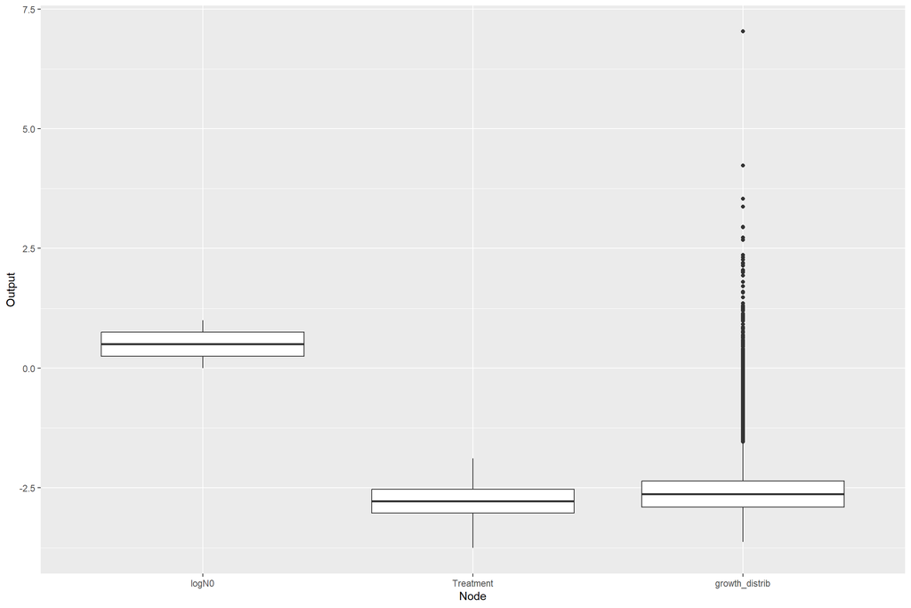

```r
plot_outputs(cases,
             chosen = c("logN0", "Treatment", "growth_distrib"))
```

**Violin plot**

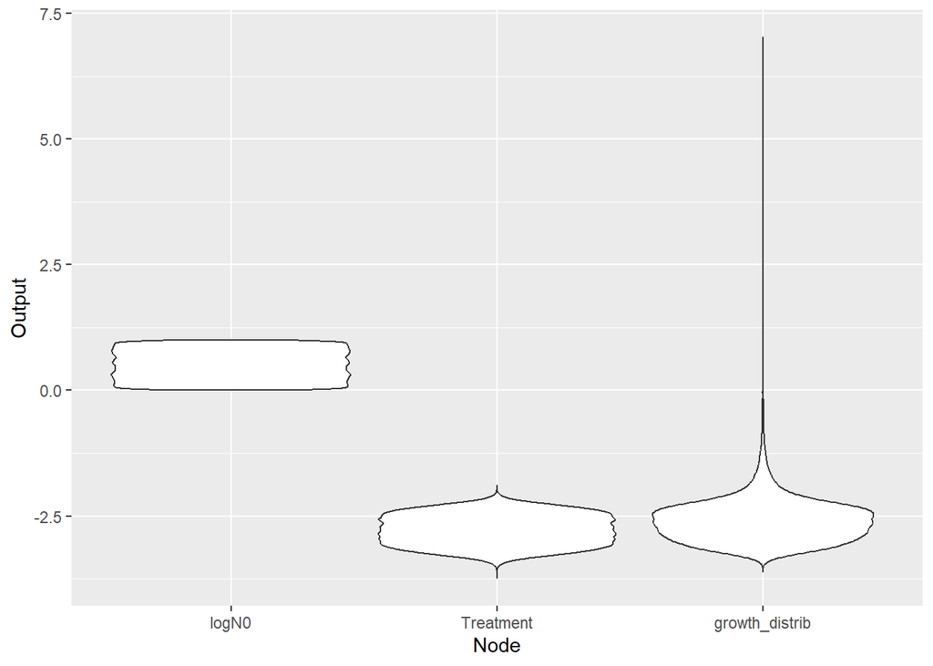

```r
plot_outputs(cases,
             chosen = c("logN0", "Treatment", "growth_distrib"),
             type = "violin")
```

**Density plot**

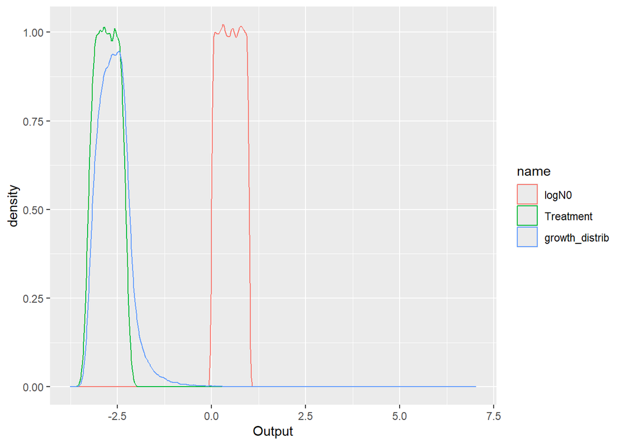

```r
plot_outputs(cases,
             chosen = c("logN0", "Treatment", "growth_distrib"),
             type = "density")
```

### Simulation as a 2D Monte Carlo

For the 2D-MC simulation we need two inputs, the number of simulations for level 0 (variability) and the number of simulations for level 1 (uncertainty). We will use 1000 iterations for variability and 100 for uncertainty. We will visualize the results for growth distribution with a density plot that compares the distribution from the variability (blue) with the distribution including all sources of variation (variability & uncertainty)(grey).

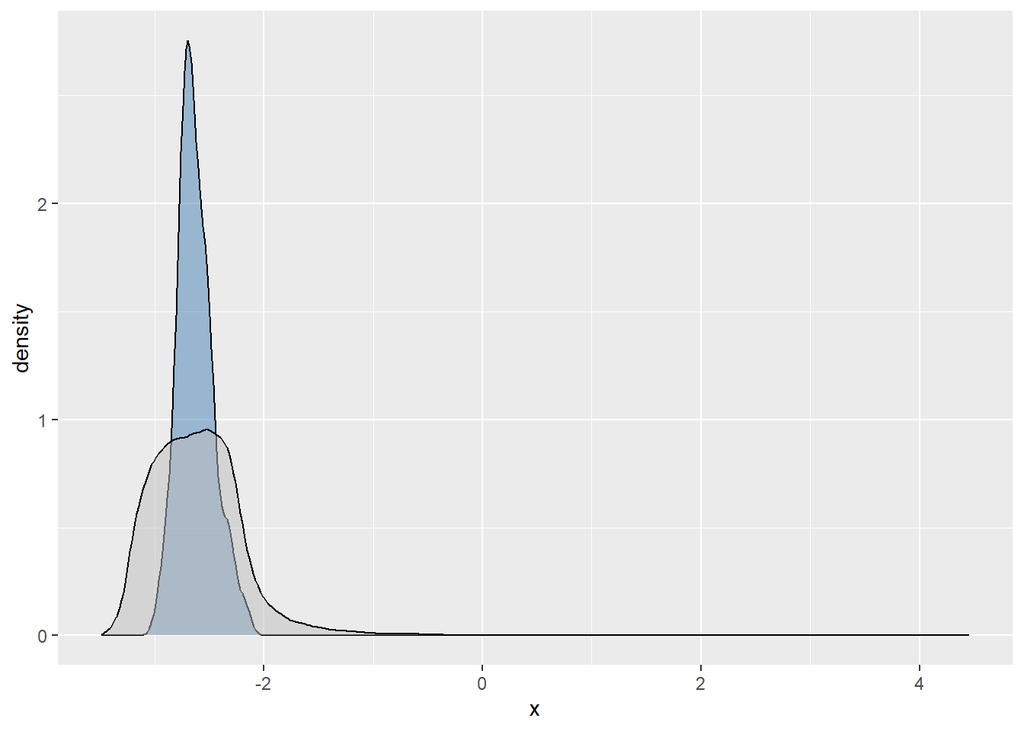

```r
cases$simulate_2D(1000, 100, seed = 792)
growth_distrib$density_plot_2D()
```

Also, we will visualize the cumulative distribution where the line represents the level 0 (variability) and the ribbon the additional variation due to the uncertainty level.

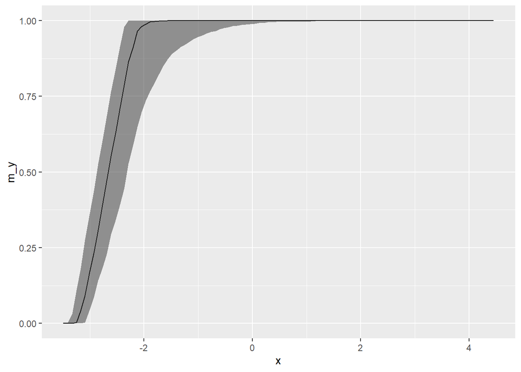

```r
growth_distrib$cummulative_plot_2D()
```

And our quantiles, as we did before. In this case, the quantiles are calculated both under level 0 (variability) and over the complete model (variability & uncertainty). Note that the quantiles for level 1 are practically identical to those calculated above for the 1D Monte Carlo simulation.:

```r
quantile_table_2D(cases, chosen = c("cases", "Pill", "dose", "growth_distrib"),
               probs = c(0.50, 0.90, 0.99))
```

```
# A tibble: 4 × 7
  node         `0.5_level1` `0.9_level1` `0.99_level1` `0.5_level0` `0.9_level0`
  <chr>               <dbl>        <dbl>         <dbl>        <dbl>        <dbl>
1 growth_dist…    -2.64e+ 0    -2.16e+ 0     -1.21e+ 0    -2.66e+ 0    -2.44e+ 0
2 dose             1   e+ 0     3   e+ 0      2.2 e+ 1     1   e+ 0     2   e+ 0
3 Pill             1.00e-12     3.00e-12      2.20e-11     1.00e-12     2.00e-12
4 cases            0            4   e+ 0      2.2 e+ 1     0            1   e+ 0
# ℹ 1 more variable: `0.99_level0` <dbl>
```